# Rus- og tobakksundersøkelsen 2026

## tobe1

*Har du tidligere brukt vape/e-sigaretter/fordampere*

| Feature | Result |
| --- | --- |
| Variable type | haven_labelled |
| Number of missing obs. | 232 (4.97 %) |
| Number of unique values | 5 |
| Mode | “Nei” |

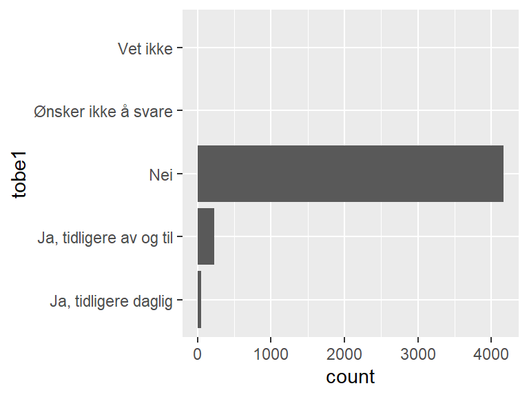

- Note that the following levels have at most five observations: "Vet ikke", "Ønsker ikke å svare".

## tobald

*Hvor gammel var du da du begynte å bruke vape/e-sigaretter regelmessig*

| Feature | Result |
| --- | --- |
| Variable type | numeric |
| Number of missing obs. | 4183 (89.53 %) |
| Number of unique values | 57 |
| Median | 25 |
| 1st and 3rd quartiles | 17; 45 |
| Min. and max. | 10; 999 |

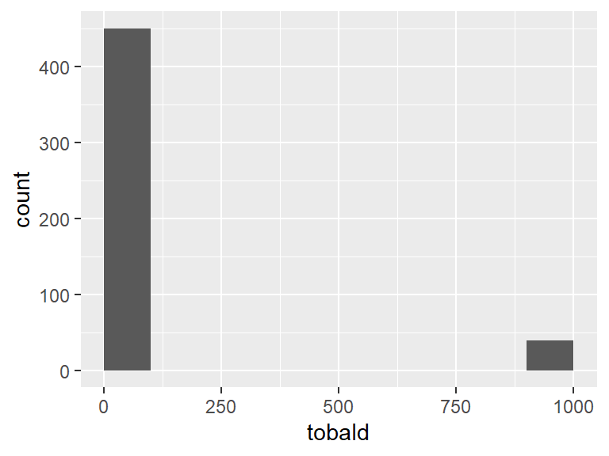

- Note that the following possible outlier values were detected: "10", "998", "999".

## tobe3

*Hvilken type vape/e-sigaretter/fordamper bruker du/brukte du i hovedsak*

| Feature | Result |
| --- | --- |
| Variable type | haven_labelled |
| Number of missing obs. | 4183 (89.53 %) |
| Number of unique values | 5 |
| Mode | “Engangs e-sigarett/fordamper som ikke er oppladbar («disposable», «puff bar», «elf bar» eller «cigalike»)” |

[figure not shown]

- Note that the following levels have at most five observations: "Ønsker ikke å svare".

## tobe4

*Hva er/var nikotininnholdet i væsken i de vape/e-sigarettene du vanligvis bruker/brukte*

| Feature | Result |
| --- | --- |
| Variable type | haven_labelled |
| Number of missing obs. | 4183 (89.53 %) |
| Number of unique values | 7 |
| Mode | “Vet ikke” |

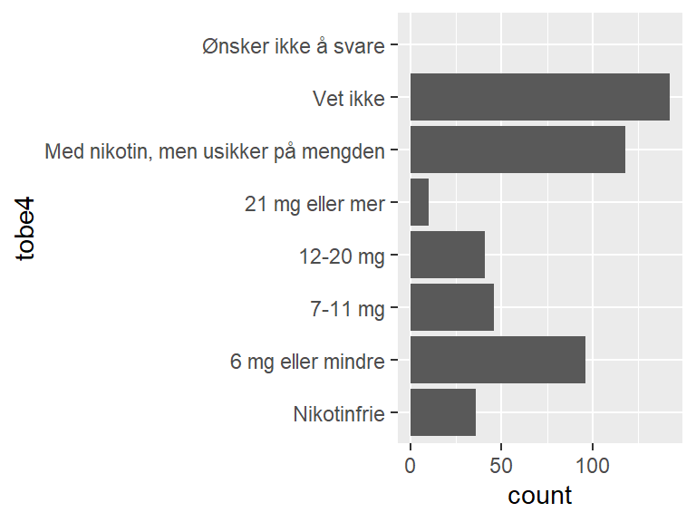

## tob60

*Bruker du snus daglig, av og til eller aldri*

| Feature | Result |
| --- | --- |
| Variable type | haven_labelled |
| Number of missing obs. | 0 (0 %) |
| Number of unique values | 5 |
| Mode | “Aldri” |

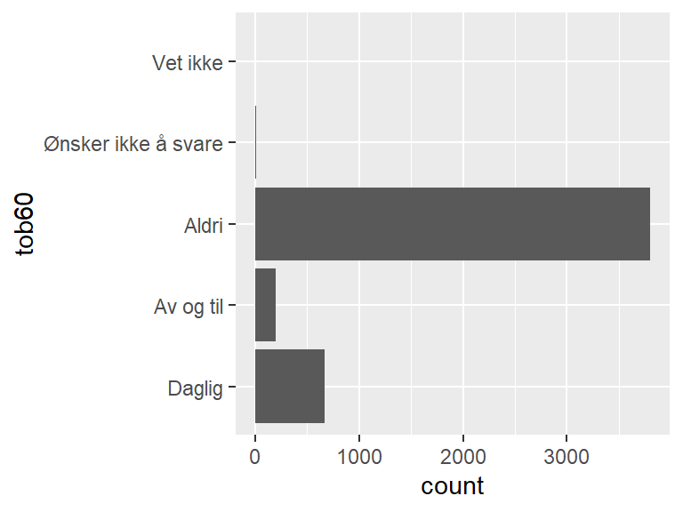

- Note that the following levels have at most five observations: "Vet ikke".

## tob64any

*Har du brukt snus tidligere*

| Feature | Result |
| --- | --- |
| Variable type | haven_labelled |
| Number of missing obs. | 874 (18.71 %) |
| Number of unique values | 5 |
| Mode | “Nei” |

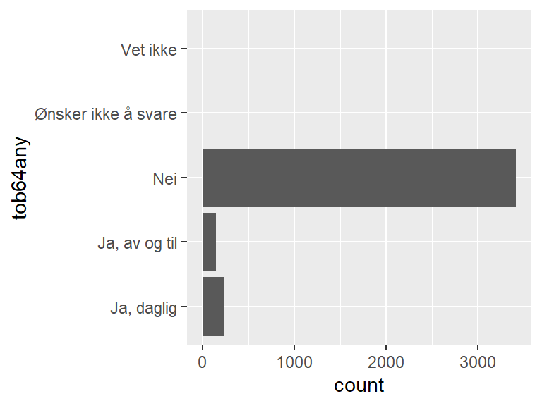

- Note that the following levels have at most five observations: "Vet ikke", "Ønsker ikke å svare".

## tob64c

*Har du tidligere brukt snus daglig*

| Feature | Result |
| --- | --- |
| Variable type | haven_labelled |
| Number of missing obs. | 4474 (95.76 %) |
| Number of unique values | 2 |
| Mode | “Nei” |

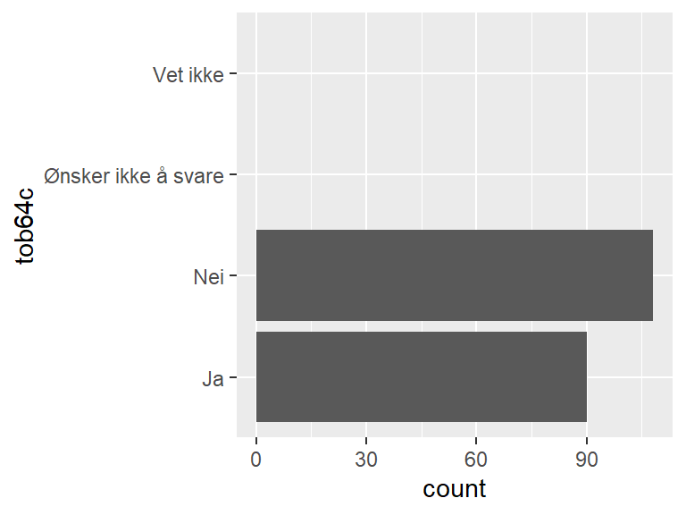

## tobprsn1

*Hvor mange pris/poser snus bruker du gjennomsnittlig pr. dag*

| Feature | Result |
| --- | --- |
| Variable type | numeric |
| Number of missing obs. | 4006 (85.74 %) |
| Number of unique values | 26 |
| Median | 10 |
| 1st and 3rd quartiles | 7; 15 |
| Min. and max. | 1; 99 |

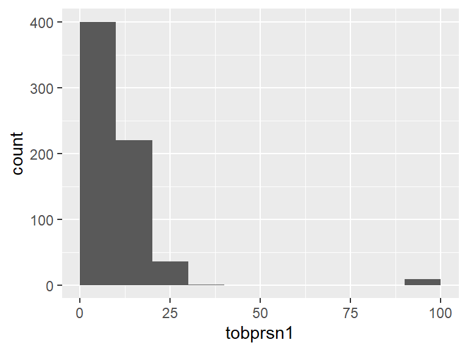

- The following suspected missing value codes enter as regular values: "99".
- Note that the following possible outlier values were detected: "1", "2", "99".

## tobprsn2

*Hvor mange pris/poser snus bruker du gjennomsnittlig pr. uke*

| Feature | Result |
| --- | --- |
| Variable type | numeric |
| Number of missing obs. | 4474 (95.76 %) |
| Number of unique values | 24 |
| Median | 3 |
| 1st and 3rd quartiles | 1; 18.75 |
| Min. and max. | 0; 99 |

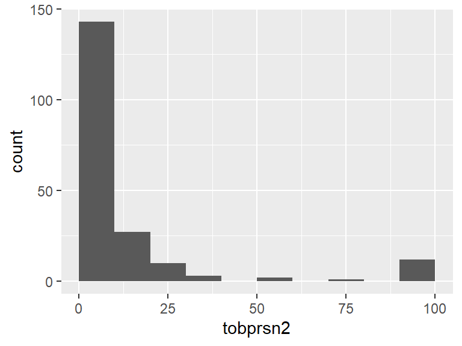

## tob66

*Hva slags snus bruker du hovedsakelig, porsjonssnus (poser) eller løssnus*

| Feature | Result |
| --- | --- |
| Variable type | haven_labelled |
| Number of missing obs. | 3808 (81.51 %) |
| Number of unique values | 7 |
| Mode | “Porsjonssnus” |

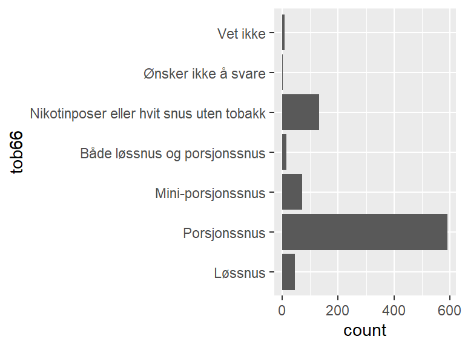

- Note that the following levels have at most five observations: "Ønsker ikke å svare".

## tob68

*Hvor gammel var du da du begynte å bruke snus regelmessig*

| Feature | Result |
| --- | --- |
| Variable type | numeric |
| Number of missing obs. | 3429 (73.39 %) |
| Number of unique values | 63 |
| Median | 20 |
| 1st and 3rd quartiles | 17; 31 |
| Min. and max. | 10; 99 |

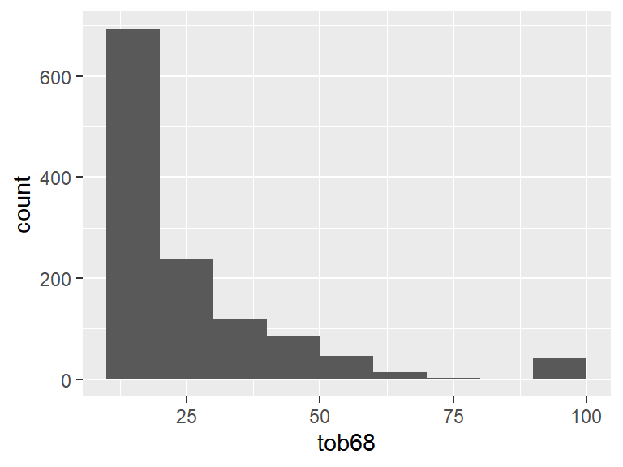

- Note that the following possible outlier values were detected: "10", "12", "13", "14", "15".

## tob69

*Hva begynte du med først, snus eller sigaretter*

| Feature | Result |
| --- | --- |
| Variable type | haven_labelled |
| Number of missing obs. | 3821 (81.79 %) |
| Number of unique values | 4 |
| Mode | “Begynte med sigaretter først” |

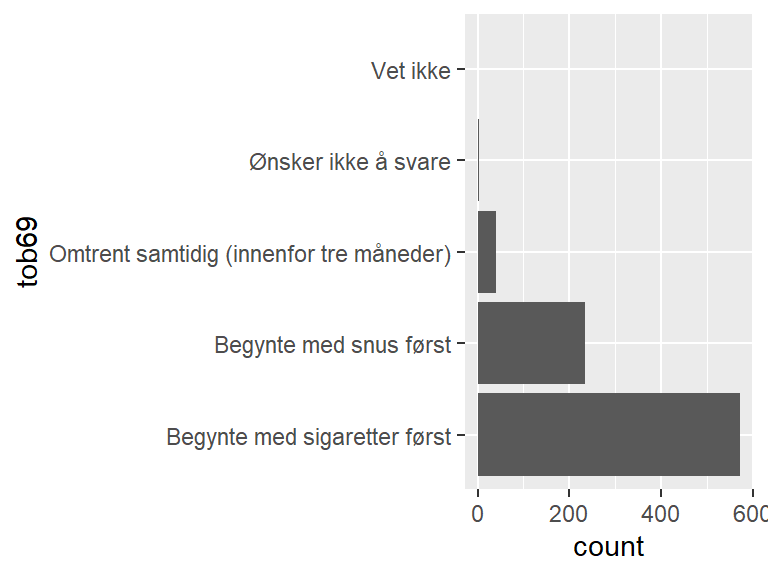

- Note that the following levels have at most five observations: "Ønsker ikke å svare".

## tob69b

*Bruker du noen former for nikotinerstatningsprodukter nå*

| Feature | Result |
| --- | --- |
| Variable type | haven_labelled |
| Number of missing obs. | 2043 (43.73 %) |
| Number of unique values | 3 |
| Mode | “Nei” |

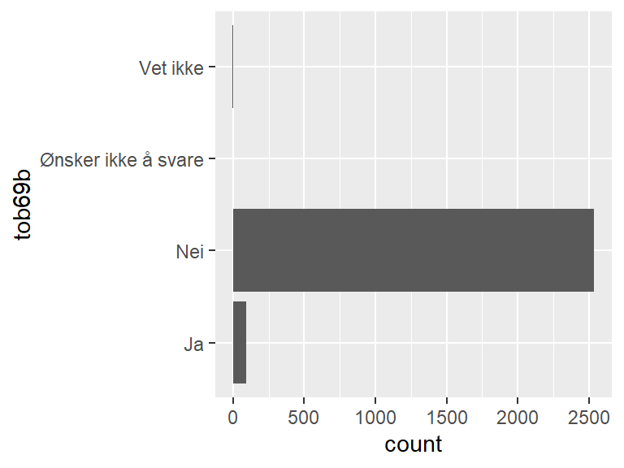

- Note that the following levels have at most five observations: "Vet ikke".

## tob71

*Vurderer du seriøst å slutte å bruke snus de neste 6 månedene*

| Feature | Result |
| --- | --- |
| Variable type | haven_labelled |
| Number of missing obs. | 3808 (81.51 %) |
| Number of unique values | 4 |
| Mode | “Nei” |

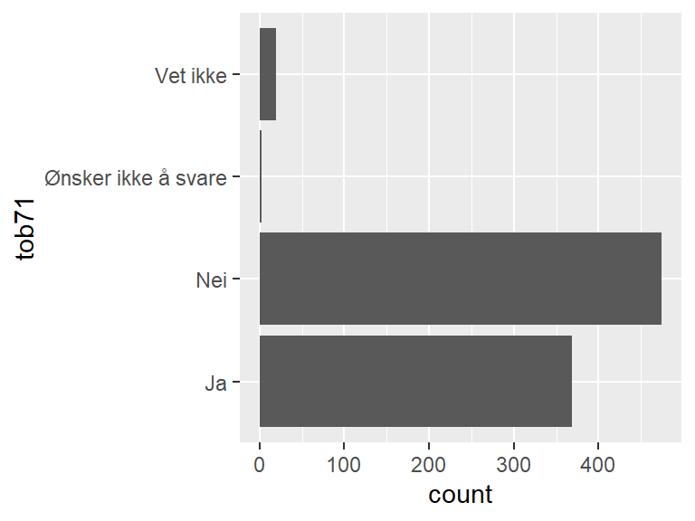

- Note that the following levels have at most five observations: "Ønsker ikke å svare".

## tobsluttsn1

*Har du noen gang prøvd å slutte med snus*

| Feature | Result |
| --- | --- |
| Variable type | haven_labelled |
| Number of missing obs. | 3808 (81.51 %) |
| Number of unique values | 5 |
| Mode | “Nei” |

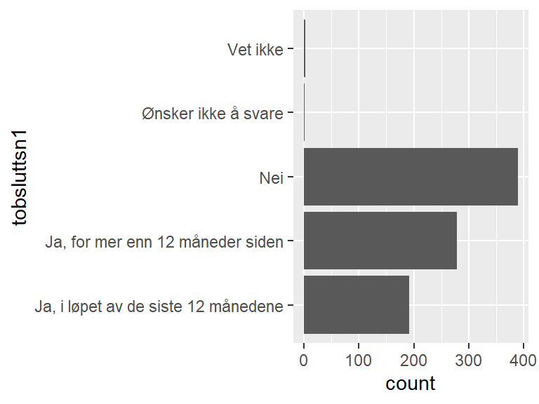

- Note that the following levels have at most five observations: "Vet ikke", "Ønsker ikke å svare".

## tobsluttsn2

*Hvilket år sluttet du med snus*

| Feature | Result |
| --- | --- |
| Variable type | numeric |
| Number of missing obs. | 4293 (91.89 %) |
| Number of unique values | 45 |
| Median | 2020 |
| 1st and 3rd quartiles | 2011; 2024 |
| Min. and max. | 1973; 9999 |

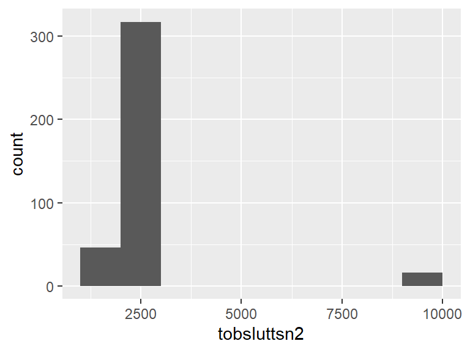

- Note that the following possible outlier values were detected: "9998", "9999".

## tob61

*Kan du prøve å forutsi dine røykevaner omkring 5 år fra nå*

| Feature | Result |
| --- | --- |
| Variable type | haven_labelled |
| Number of missing obs. | 0 (0 %) |
| Number of unique values | 6 |
| Mode | “Kommer helt sikkert ikke til å røyke daglig” |

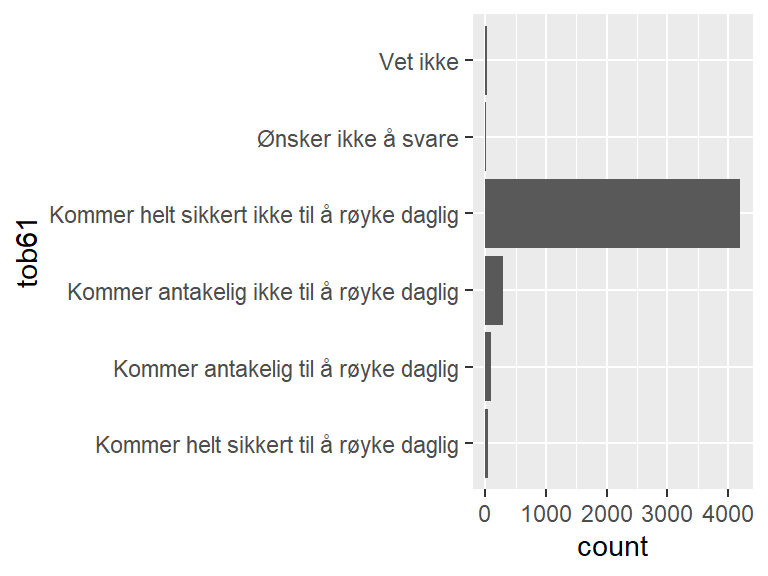

## tob61b

*Kan du prøve å forutsi dine snusvaner omkring 5 år fra nå*

| Feature | Result |
| --- | --- |
| Variable type | haven_labelled |
| Number of missing obs. | 0 (0 %) |
| Number of unique values | 6 |
| Mode | “Kommer helt sikkert ikke til å snuse daglig” |

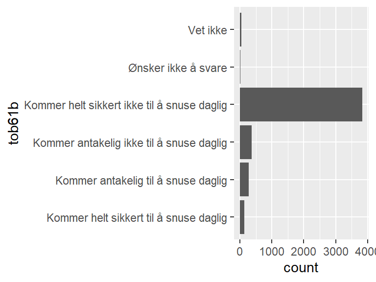

## tob62a

*Hvor skadelig tror du snus er på en skala fra 1 til 7*

| Feature | Result |
| --- | --- |
| Variable type | haven_labelled |
| Number of missing obs. | 0 (0 %) |
| Number of unique values | 9 |
| Mode | “7 Svært skadelig” |

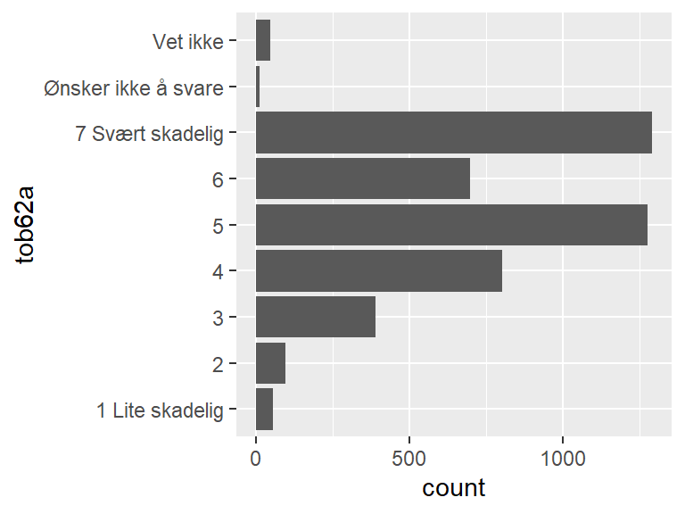

## tob62e

*Hvor skadelig tror du ferdigsigaretter med lavere nikotin- og tjæreinnhold er, på en skala fra 1 til 7*

| Feature | Result |
| --- | --- |
| Variable type | haven_labelled |
| Number of missing obs. | 0 (0 %) |
| Number of unique values | 9 |
| Mode | “7 Svært skadelig” |

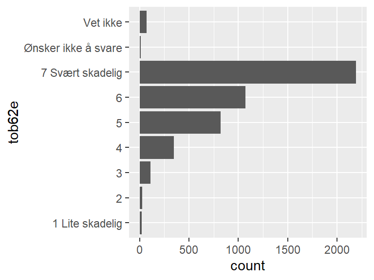

## tob62f

*Hvor skadelig tror du vanlige ferdigsigaretter er, på en skala fra 1 til 7*

| Feature | Result |
| --- | --- |
| Variable type | haven_labelled |
| Number of missing obs. | 0 (0 %) |
| Number of unique values | 9 |
| Mode | “7 Svært skadelig” |

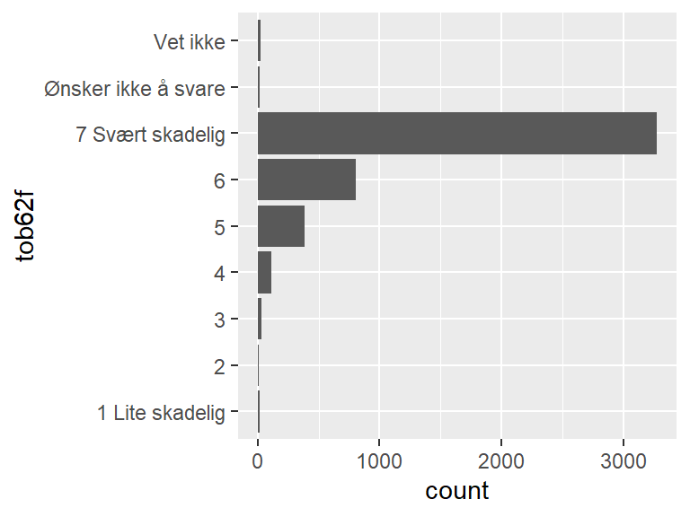

## tob62g

*Hvor skadelig tror du produkter som er laget for å erstatte tobakksprodukter med nikotin på en skala fra 1 til 7*

| Feature | Result |
| --- | --- |
| Variable type | haven_labelled |
| Number of missing obs. | 0 (0 %) |
| Number of unique values | 9 |
| Mode | “4” |

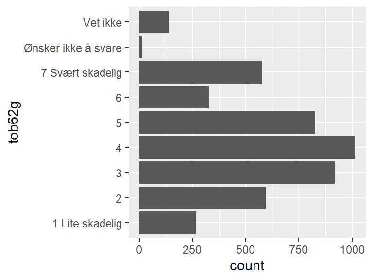

## tob62h

*Hvor skadelig tror du e-sigaretter/fordampere (vape) er, på en skala fra 1 til 7*

| Feature | Result |
| --- | --- |
| Variable type | haven_labelled |
| Number of missing obs. | 0 (0 %) |
| Number of unique values | 9 |
| Mode | “7 Svært skadelig” |

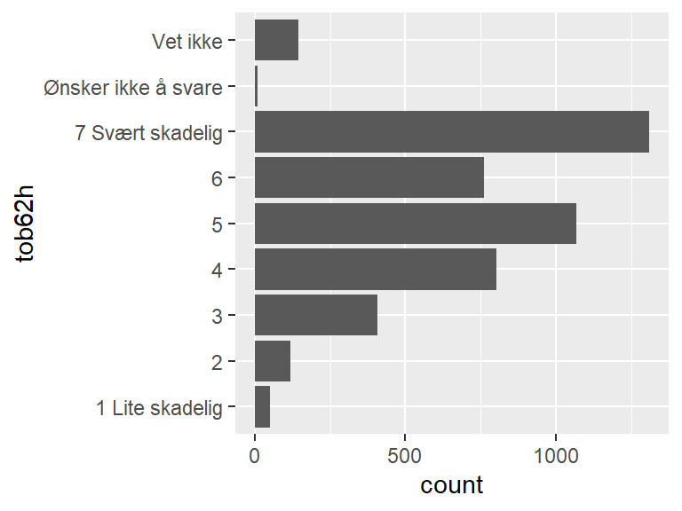

## tobsit_1

*I hvilke situasjoner røyker du vanligvis*

| Feature | Result |
| --- | --- |
| Variable type | haven_labelled |
| Number of missing obs. | 4287 (91.76 %) |
| Number of unique values | 6 |
| Mode | “I sosiale sammenkomster med andre” |

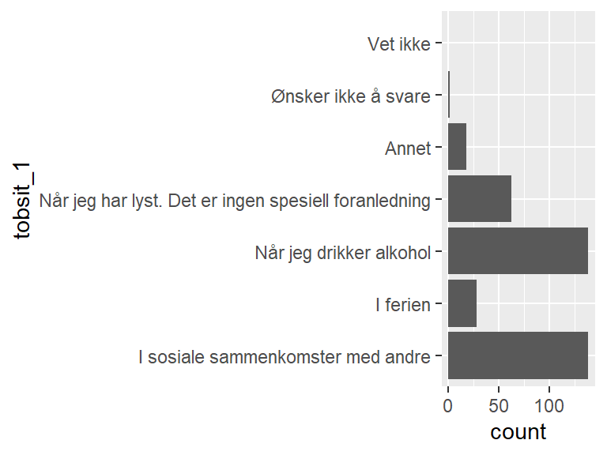

- Note that the following levels have at most five observations: "Ønsker ikke å svare".

## tobsit_2

*I hvilke situasjoner røyker du vanligvis*

| Feature | Result |
| --- | --- |
| Variable type | haven_labelled |
| Number of missing obs. | 4517 (96.68 %) |
| Number of unique values | 5 |
| Mode | “Når jeg drikker alkohol” |

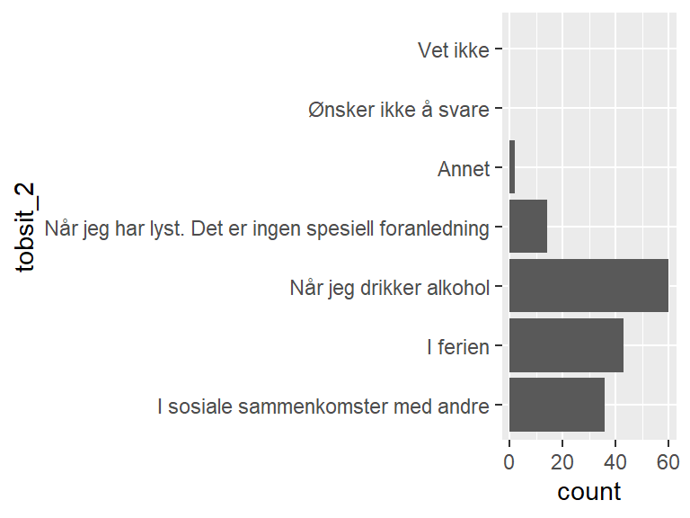

- Note that the following levels have at most five observations: "Annet".

## tobsit_3

*I hvilke situasjoner røyker du vanligvis*

| Feature | Result |
| --- | --- |
| Variable type | haven_labelled |
| Number of missing obs. | 4619 (98.87 %) |
| Number of unique values | 5 |
| Mode | “Når jeg drikker alkohol” |

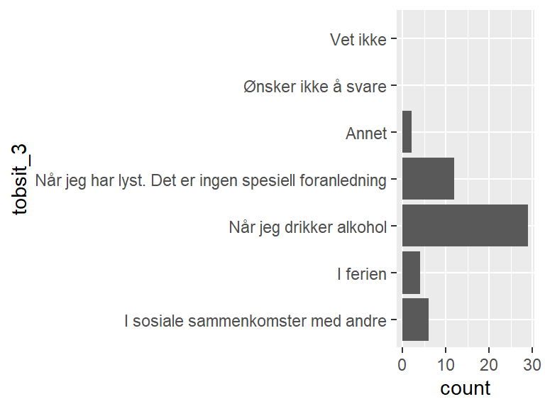

- Note that the following levels have at most five observations: "Annet", "I ferien".

## tobsit_4

*I hvilke situasjoner røyker du vanligvis*

| Feature | Result |
| --- | --- |
| Variable type | haven_labelled |
| Number of missing obs. | 4661 (99.76 %) |
| Number of unique values | 4 |
| Mode | “Når jeg har lyst. Det er ingen spesiell foranledning” |

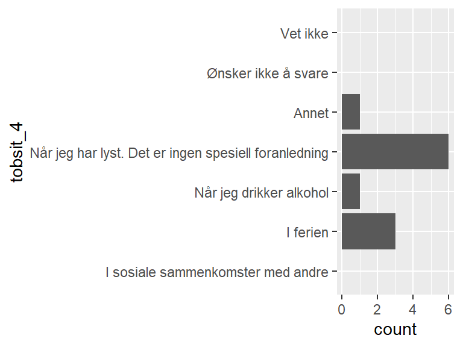

- Note that the following levels have at most five observations: "Annet", "I ferien", "Når jeg drikker alkohol".

## tobsit_5

*I hvilke situasjoner røyker du vanligvis*

| Feature | Result |
| --- | --- |
| Variable type | haven_labelled |
| Number of missing obs. | 4670 (99.96 %) |
| Number of unique values | 2 |
| Mode | “I sosiale sammenkomster med andre” |

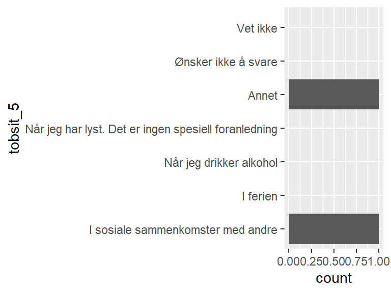

- Note that the following levels have at most five observations: "Annet", "I sosiale sammenkomster med andre".

## drukket1

*Har drukket alkohol siste 12 mnd*

| Feature | Result |
| --- | --- |
| Variable type | haven_labelled |
| Number of missing obs. | 0 (0 %) |
| Number of unique values | 4 |
| Mode | “Ja” |

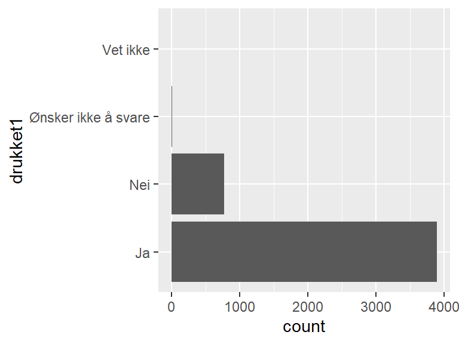

- Note that the following levels have at most five observations: "Vet ikke".

## drukk1b

*Har du noen gang drukket alkohol*

| Feature | Result |
| --- | --- |
| Variable type | haven_labelled |
| Number of missing obs. | 3903 (83.54 %) |
| Number of unique values | 3 |
| Mode | “Ja” |

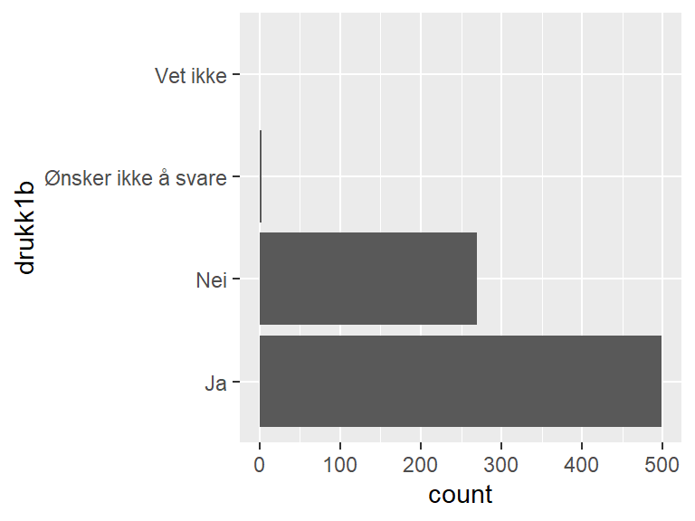

- Note that the following levels have at most five observations: "Ønsker ikke å svare".

## drukket2

*Hvor ofte drukket alkohol siste 12 mnd*

| Feature | Result |
| --- | --- |
| Variable type | haven_labelled |
| Number of missing obs. | 781 (16.72 %) |
| Number of unique values | 6 |
| Mode | “Ukentlig” |

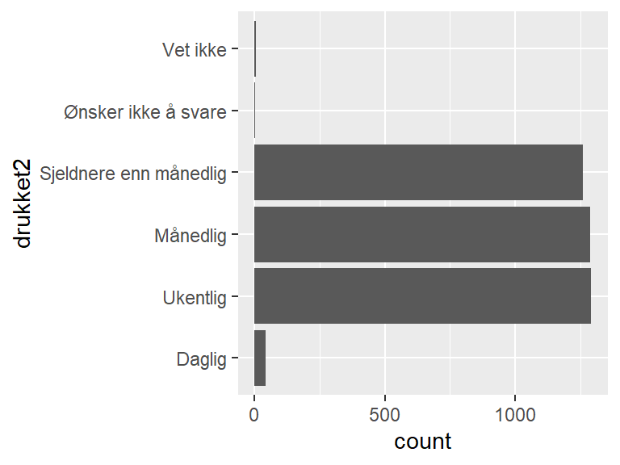

- Note that the following levels have at most five observations: "Vet ikke", "Ønsker ikke å svare".

## drukk2a

*Drukket alkohol ukentlig*

| Feature | Result |
| --- | --- |
| Variable type | haven_labelled |
| Number of missing obs. | 3380 (72.35 %) |
| Number of unique values | 4 |
| Mode | “Omtrent 1 dag i uken” |

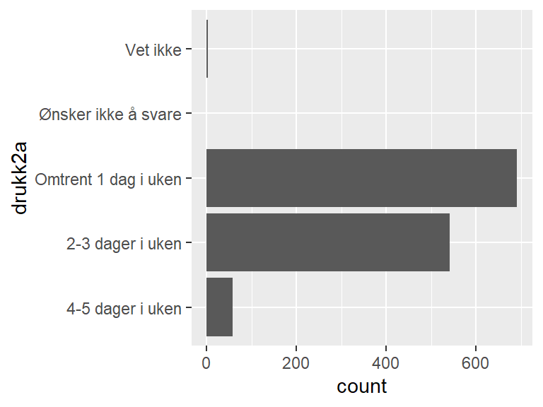

- Note that the following levels have at most five observations: "Vet ikke".

## drukk2b

*Antall dager drukket alkohol pr mnd siste 12 mnd*

| Feature | Result |
| --- | --- |
| Variable type | haven_labelled |
| Number of missing obs. | 3382 (72.39 %) |
| Number of unique values | 5 |
| Mode | “2-3 dager i måneden” |

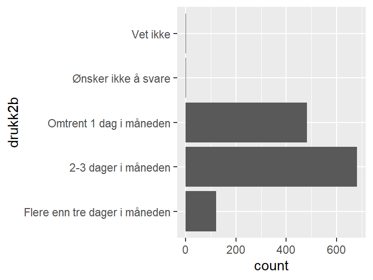

- Note that the following levels have at most five observations: "Vet ikke", "Ønsker ikke å svare".

## drukk2c

*Drukket alkohol få dager/en dag siste 12 mnd*

| Feature | Result |
| --- | --- |
| Variable type | haven_labelled |
| Number of missing obs. | 3410 (72.99 %) |
| Number of unique values | 4 |
| Mode | “Flere enn tre dager” |

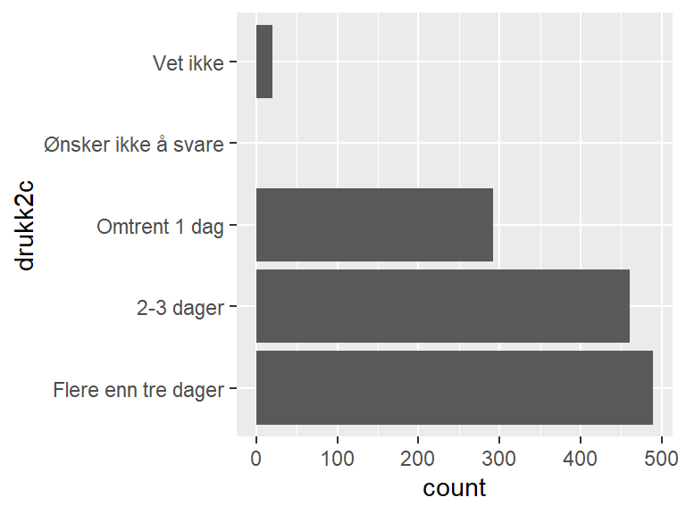

## drukket3

*Har drukket alkohol siste 4 uker*

| Feature | Result |
| --- | --- |
| Variable type | haven_labelled |
| Number of missing obs. | 781 (16.72 %) |
| Number of unique values | 4 |
| Mode | “Ja” |

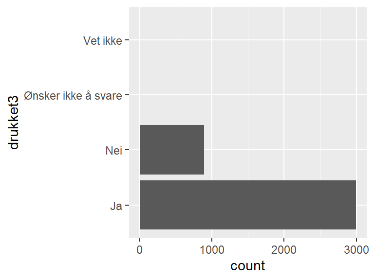

- Note that the following levels have at most five observations: "Vet ikke", "Ønsker ikke å svare".

## type1

*Har drukket øl siste 4 uker*

| Feature | Result |
| --- | --- |
| Variable type | haven_labelled |
| Number of missing obs. | 1678 (35.92 %) |
| Number of unique values | 3 |
| Mode | “Ja” |

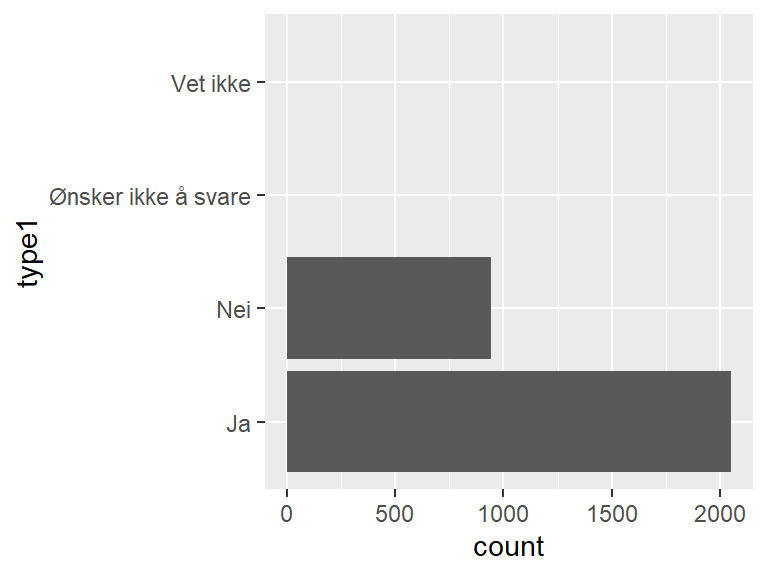

- Note that the following levels have at most five observations: "Vet ikke".

## type2

*Har drukket vin siste 4 uker*

| Feature | Result |
| --- | --- |
| Variable type | haven_labelled |
| Number of missing obs. | 1678 (35.92 %) |
| Number of unique values | 3 |
| Mode | “Ja” |

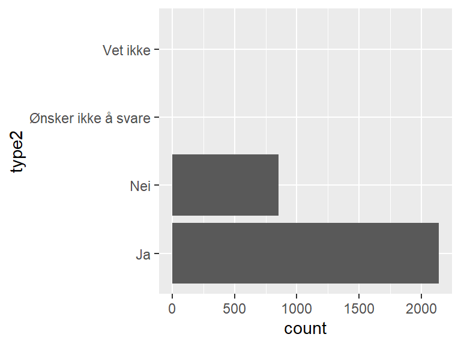

- Note that the following levels have at most five observations: "Vet ikke".

## type3

*Har drukket brennevin siste 4 uker*

| Feature | Result |
| --- | --- |
| Variable type | haven_labelled |
| Number of missing obs. | 1678 (35.92 %) |
| Number of unique values | 3 |
| Mode | “Nei” |

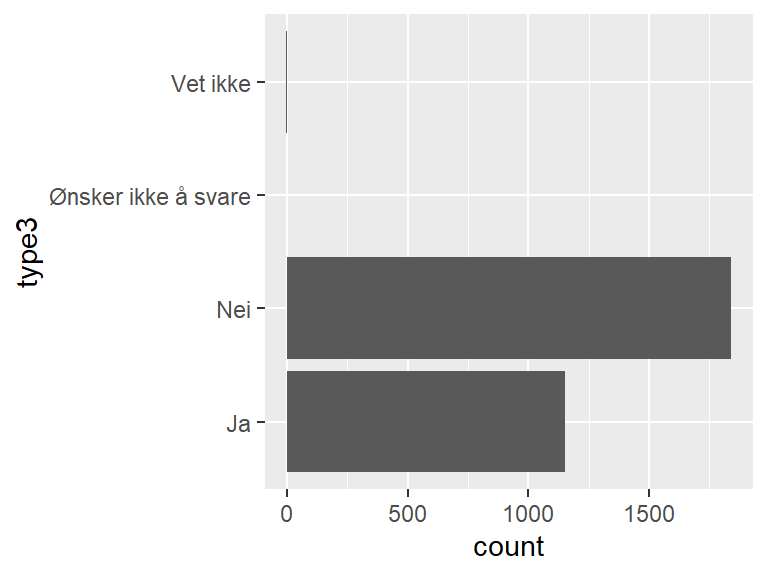

- Note that the following levels have at most five observations: "Vet ikke".

## type4

*Har drukket rusbrus/cider siste 4 uker*

| Feature | Result |
| --- | --- |
| Variable type | haven_labelled |
| Number of missing obs. | 1678 (35.92 %) |
| Number of unique values | 3 |
| Mode | “Nei” |

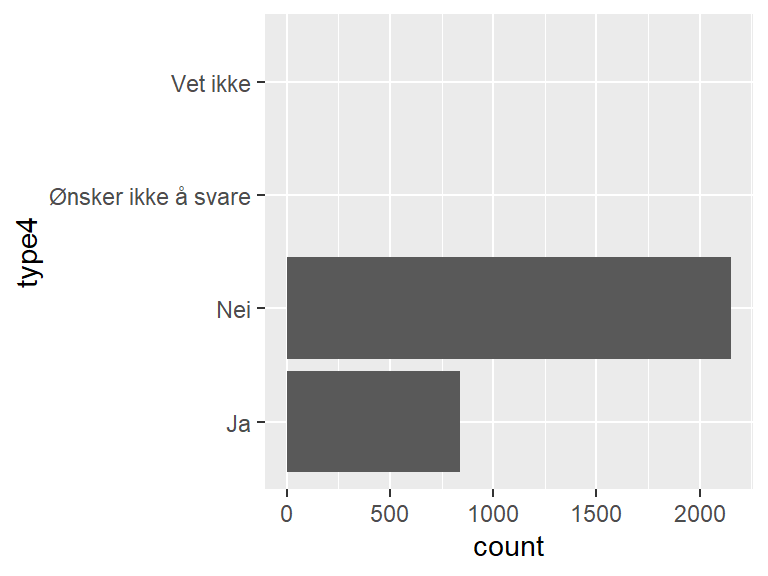

- Note that the following levels have at most five observations: "Vet ikke".

## type1a

*Hvor ofte drukket øl siste 4 uker?*

| Feature | Result |
| --- | --- |
| Variable type | haven_labelled |
| Number of missing obs. | 2623 (56.14 %) |
| Number of unique values | 4 |
| Mode | “Sjeldnere enn ukentlig” |

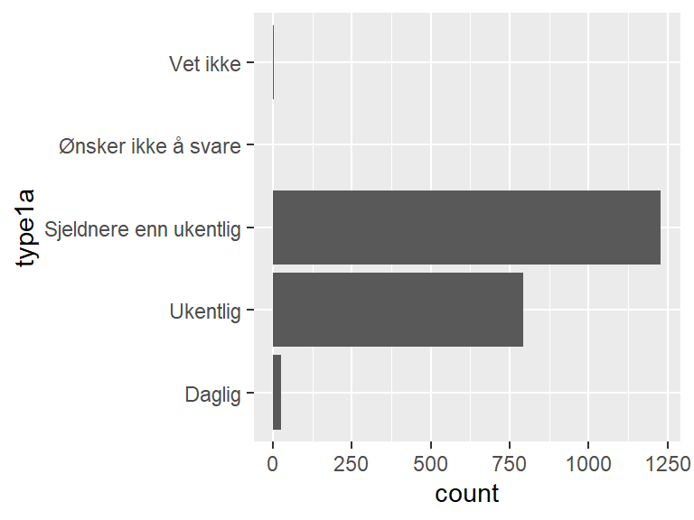

- Note that the following levels have at most five observations: "Vet ikke".

## typ1a_uk

*Ukentlig: Ant dager i uken drukket øl siste 4 uker?*

| Feature | Result |
| --- | --- |
| Variable type | haven_labelled |
| Number of missing obs. | 3879 (83.03 %) |
| Number of unique values | 3 |
| Mode | “Omtrent 1 dag i uken” |

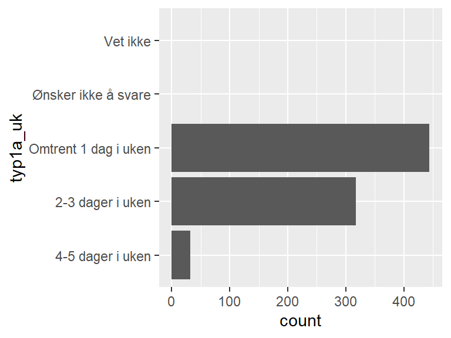

## typ1a_mn

*Månedlig: Ant dager i uken drukket øl siste 4 uker?*

| Feature | Result |
| --- | --- |
| Variable type | haven_labelled |
| Number of missing obs. | 3443 (73.69 %) |
| Number of unique values | 5 |
| Mode | “Omtrent 1 dag” |

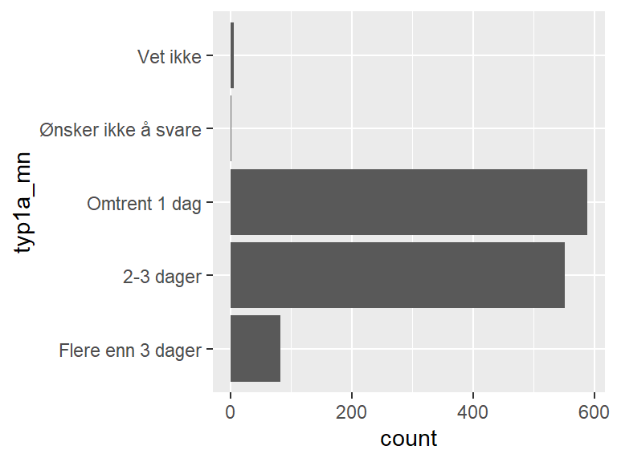

- Note that the following levels have at most five observations: "Ønsker ikke å svare".

## type1b_1

*Mengdeenhet øl*

| Feature | Result |
| --- | --- |
| Variable type | haven_labelled |
| Number of missing obs. | 3854 (82.49 %) |
| Number of unique values | 4 |
| Mode | “0,5 liter” |

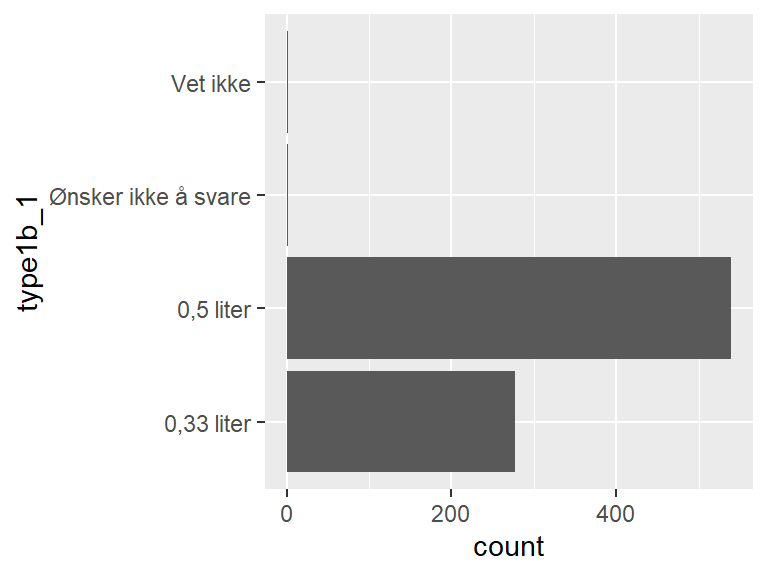

- Note that the following levels have at most five observations: "Vet ikke", "Ønsker ikke å svare".

## type1b_2

*Mengdeenhet øl*

| Feature | Result |
| --- | --- |
| Variable type | haven_labelled |
| Number of missing obs. | 4658 (99.7 %) |
| Number of unique values | 2 |
| Mode | “0,5 liter” |

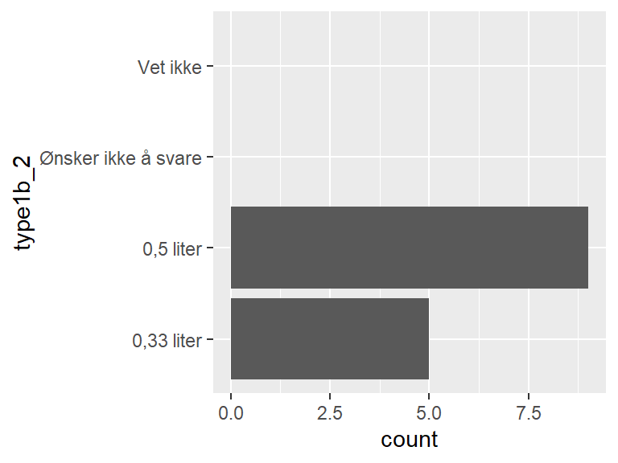

- Note that the following levels have at most five observations: "0,33 liter".

## type1b_12

*Ukentlig: Gjennomsnitt ant 0,33 l øl drukket siste 4 uker?*

| Feature | Result |
| --- | --- |
| Variable type | numeric |
| Number of missing obs. | 4390 (93.96 %) |
| Number of unique values | 18 |
| Median | 3 |
| 1st and 3rd quartiles | 2; 5 |
| Min. and max. | 0.3; 99999 |

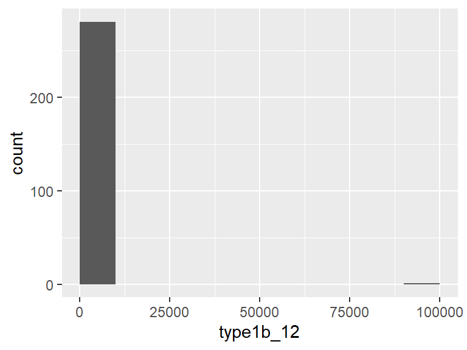

- The following suspected missing value codes enter as regular values: "99999".
- Note that the following possible outlier values were detected: "0.3", "20", "24", "28", "30", "99999".

## type1b_22

*Ukentlig: Gjennomsnitt ant 0,5 l øl drukket siste 4 uker?*

| Feature | Result |
| --- | --- |
| Variable type | numeric |
| Number of missing obs. | 4124 (88.27 %) |
| Number of unique values | 25 |
| Median | 4 |
| 1st and 3rd quartiles | 2; 6 |
| Min. and max. | 1; 99999 |

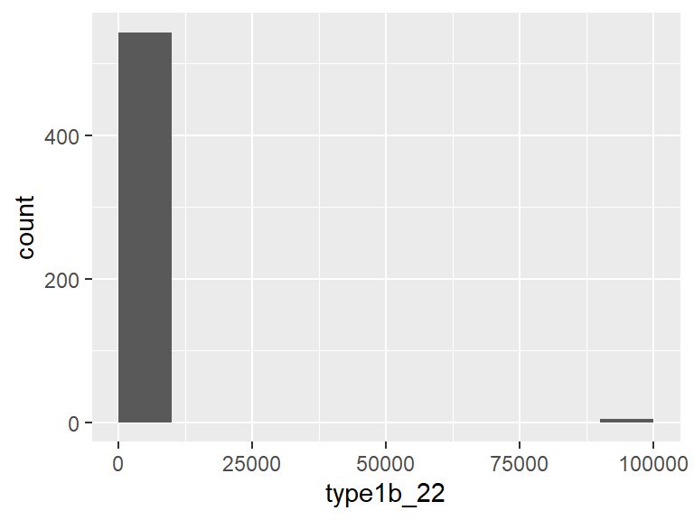

- Note that the following possible outlier values were detected: "24", "25", "30", "42", "80", "100", "99998", "99999".

## type1c_1

*Mengdeenhet øl*

| Feature | Result |
| --- | --- |
| Variable type | haven_labelled |
| Number of missing obs. | 3443 (73.69 %) |
| Number of unique values | 4 |
| Mode | “0,33 liter” |

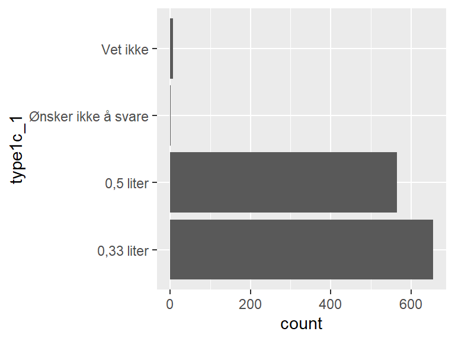

- Note that the following levels have at most five observations: "Ønsker ikke å svare".

## type1c_2

*Mengdeenhet øl*

| Feature | Result |
| --- | --- |
| Variable type | haven_labelled |
| Number of missing obs. | 4647 (99.46 %) |
| Number of unique values | 2 |
| Mode | “0,5 liter” |

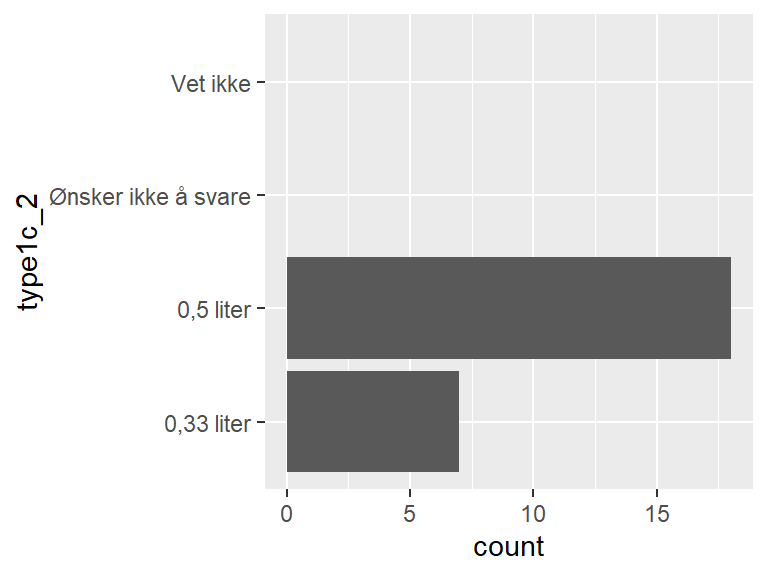

## type1c_12

*Månedlig: Antall 0,33 l øl drukket siste 4 uker?*

| Feature | Result |
| --- | --- |
| Variable type | numeric |
| Number of missing obs. | 4011 (85.85 %) |
| Number of unique values | 24 |
| Median | 3 |
| 1st and 3rd quartiles | 2; 5 |
| Min. and max. | 0.1; 99999 |

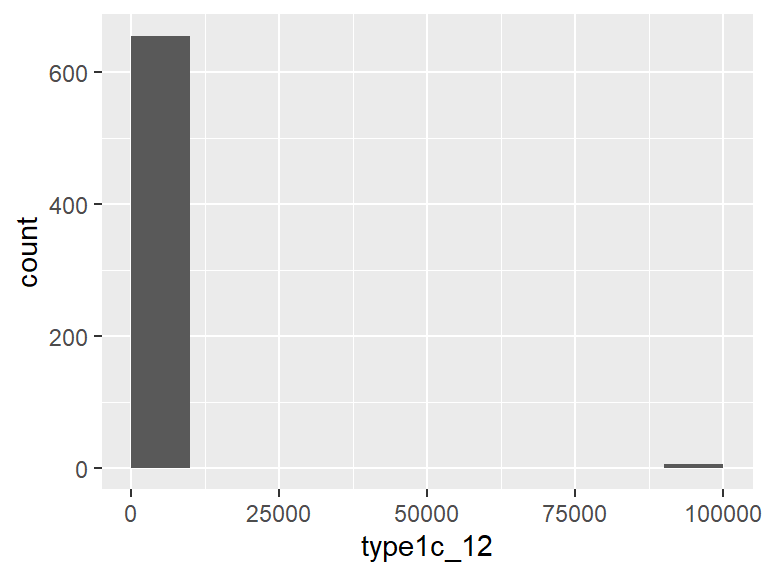

- Note that the following possible outlier values were detected: "0.1", "0.2", "0.6", "20", "24", "25", "30", "99998", "99999".

## type1c_22

*Månedlig: Antall 0,5 l øl drukket siste 4 uker?*

| Feature | Result |
| --- | --- |
| Variable type | numeric |
| Number of missing obs. | 4089 (87.52 %) |
| Number of unique values | 25 |
| Median | 4 |
| 1st and 3rd quartiles | 2; 6 |
| Min. and max. | 0.5; 99999 |

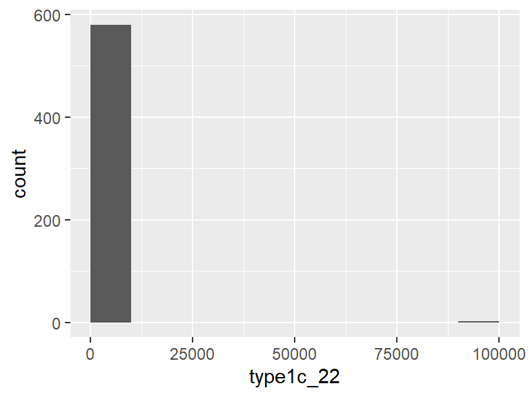

- The following suspected missing value codes enter as regular values: "99999".
- Note that the following possible outlier values were detected: "24", "25", "30", "100", "99999".

## type2a

*Hvor ofte drukket vin siste 4 uker?*

| Feature | Result |
| --- | --- |
| Variable type | haven_labelled |
| Number of missing obs. | 2535 (54.26 %) |
| Number of unique values | 4 |
| Mode | “Sjeldnere enn ukentlig” |

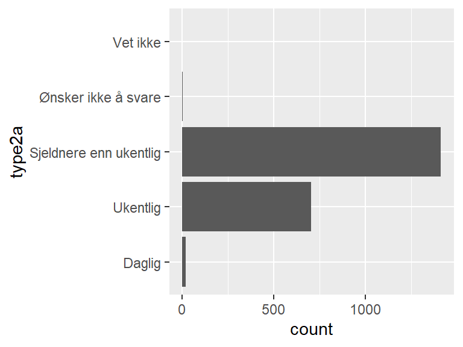

- Note that the following levels have at most five observations: "Ønsker ikke å svare".

## typ2a_uk

*Ukentlig: Ant dager i uken drukket vin siste 4 uker?*

| Feature | Result |
| --- | --- |
| Variable type | haven_labelled |
| Number of missing obs. | 3968 (84.93 %) |
| Number of unique values | 4 |
| Mode | “Omtrent 1 dag i uken” |

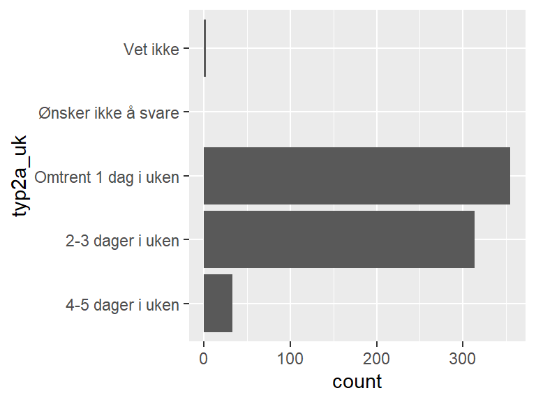

- Note that the following levels have at most five observations: "Vet ikke".

## typ2a_mn

*Månedlig: Ant dager i uken drukket vin siste 4 uker?*

| Feature | Result |
| --- | --- |
| Variable type | haven_labelled |
| Number of missing obs. | 3259 (69.76 %) |
| Number of unique values | 5 |
| Mode | “Omtrent 1 dag” |

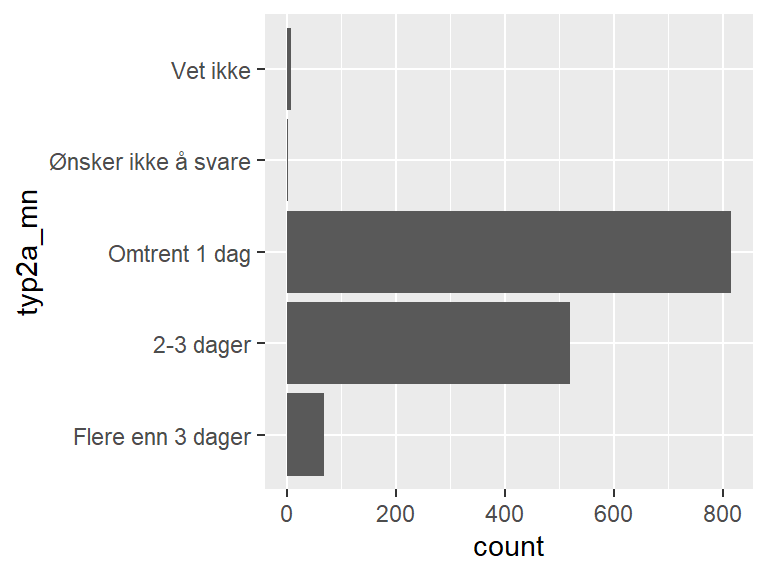

- Note that the following levels have at most five observations: "Ønsker ikke å svare".

## type2b_1

*Mengdeenhet vin*

| Feature | Result |
| --- | --- |
| Variable type | haven_labelled |
| Number of missing obs. | 3950 (84.55 %) |
| Number of unique values | 3 |
| Mode | “Glass” |

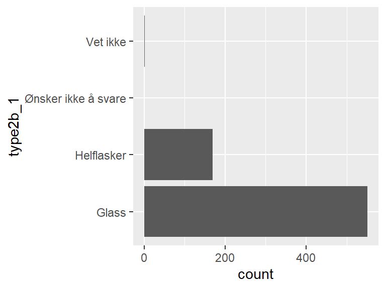

- Note that the following levels have at most five observations: "Vet ikke".

## type2b_2

*Mengdeenhet vin*

| Feature | Result |
| --- | --- |
| Variable type | haven_labelled |
| Number of missing obs. | 4670 (99.96 %) |
| Number of unique values | 2 |
| Mode | “Glass” |

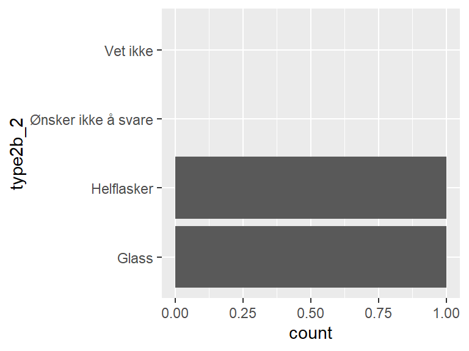

- Note that the following levels have at most five observations: "Glass", "Helflasker".

## type2b_12

*Ukentlig: Gjennomsnitt antall glass vin drukket siste 4 uker?*

| Feature | Result |
| --- | --- |
| Variable type | numeric |
| Number of missing obs. | 4120 (88.18 %) |
| Number of unique values | 25 |
| Median | 3 |
| 1st and 3rd quartiles | 2; 5 |
| Min. and max. | 0.7; 99999 |

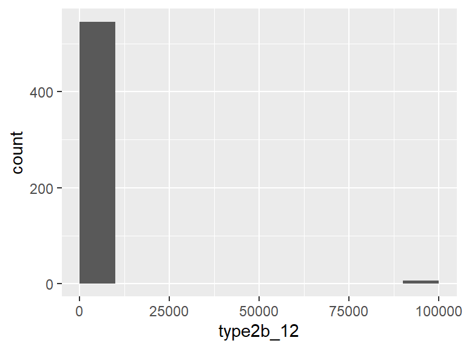

- Note that the following possible outlier values were detected: "0.7", "1", "30", "52", "99998", "99999".

## type2b_22

*Ukentlig: Gjennomsnitt antall flasker vin drukket siste 4 uker?*

| Feature | Result |
| --- | --- |
| Variable type | numeric |
| Number of missing obs. | 4502 (96.36 %) |
| Number of unique values | 14 |
| Median | 1 |
| 1st and 3rd quartiles | 1; 2 |
| Min. and max. | 0.3; 99999 |

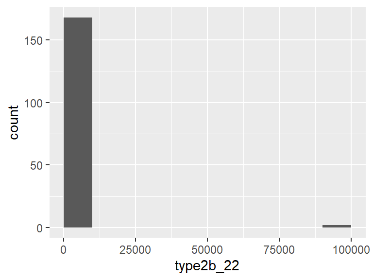

- Note that the following possible outlier values were detected: "0.3", "0.5", "99998", "99999".